# Fall 2025 Student Alerts Analysis

Harpur College, Binghamton University

Author

Data Analysis Report

## Executive Summary

This analysis examines **4583 academic alerts** raised for **3250 students** at Harpur College during Fall 2025. The central question is whether early warning alerts enable interventions that improve student outcomes.

## 1. Alert Distribution Overview

### By Alert Level

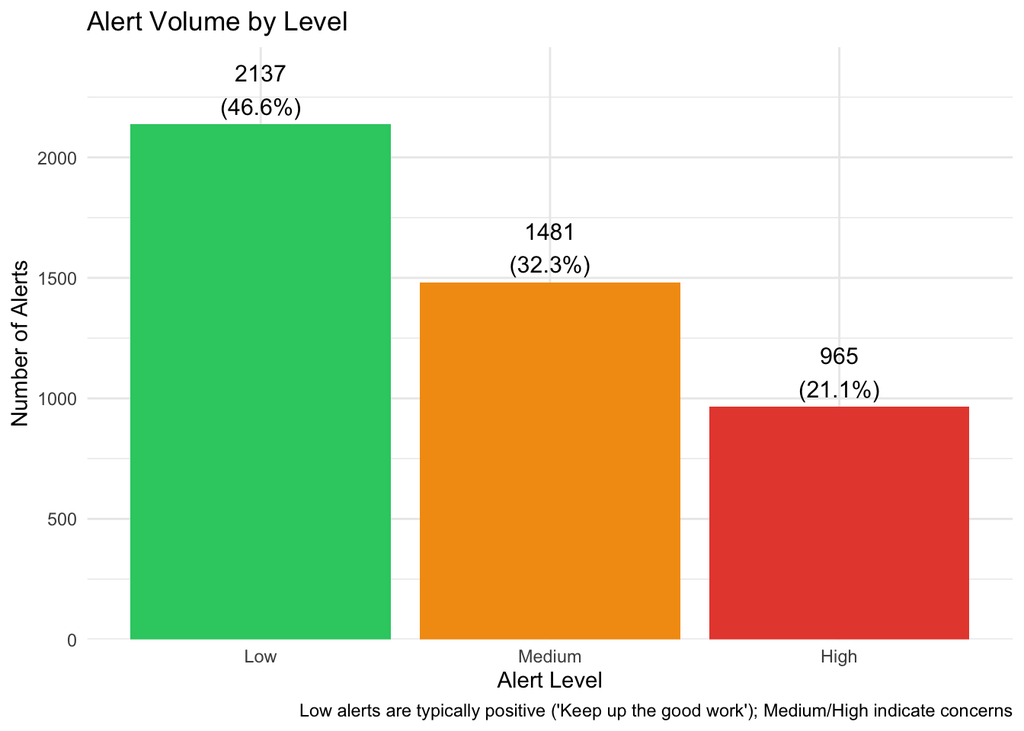

### By Alert Type

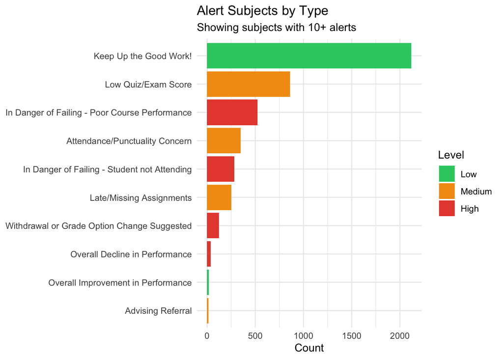

## 2. Course and Department Analysis

### Which Departments Generate the Most Alerts?

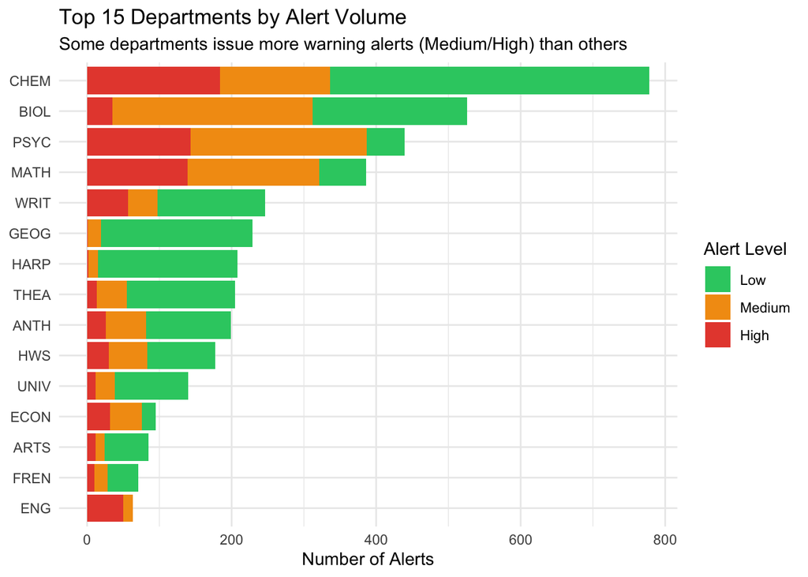

Top 10 Departments by Alert Volume

| Department | Total Alerts | Low | Medium | High | % Warning |
| --- | --- | --- | --- | --- | --- |
| CHEM | 778 | 442 | 152 | 184 | 43% |
| BIOL | 526 | 214 | 277 | 35 | 59% |
| PSYC | 439 | 52 | 244 | 143 | 88% |
| MATH | 386 | 65 | 182 | 139 | 83% |
| WRIT | 246 | 149 | 40 | 57 | 39% |
| GEOG | 229 | 210 | 18 | 1 | 8% |
| HARP | 208 | 193 | 13 | 2 | 7% |
| THEA | 205 | 150 | 42 | 13 | 27% |
| ANTH | 199 | 117 | 56 | 26 | 41% |
| HWS | 177 | 94 | 53 | 30 | 47% |

### Department Alert Patterns and Outcomes

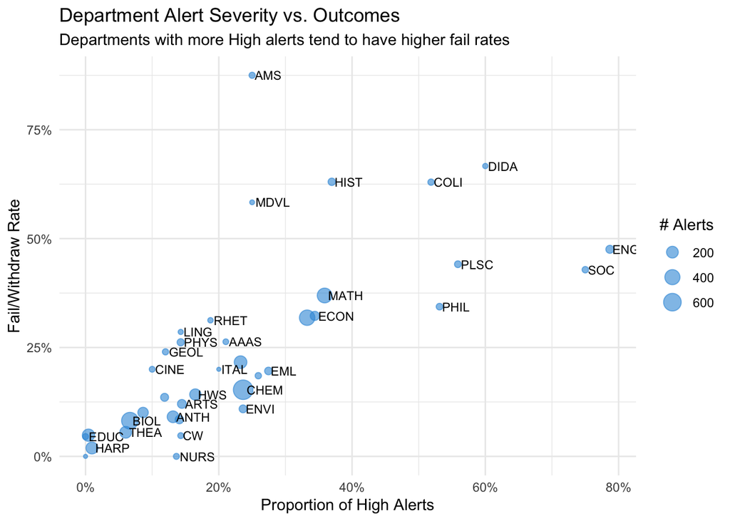

### Which Instructors Submit the Most Alerts?

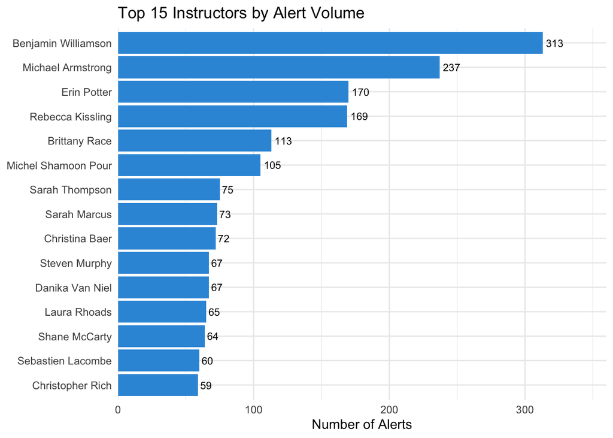

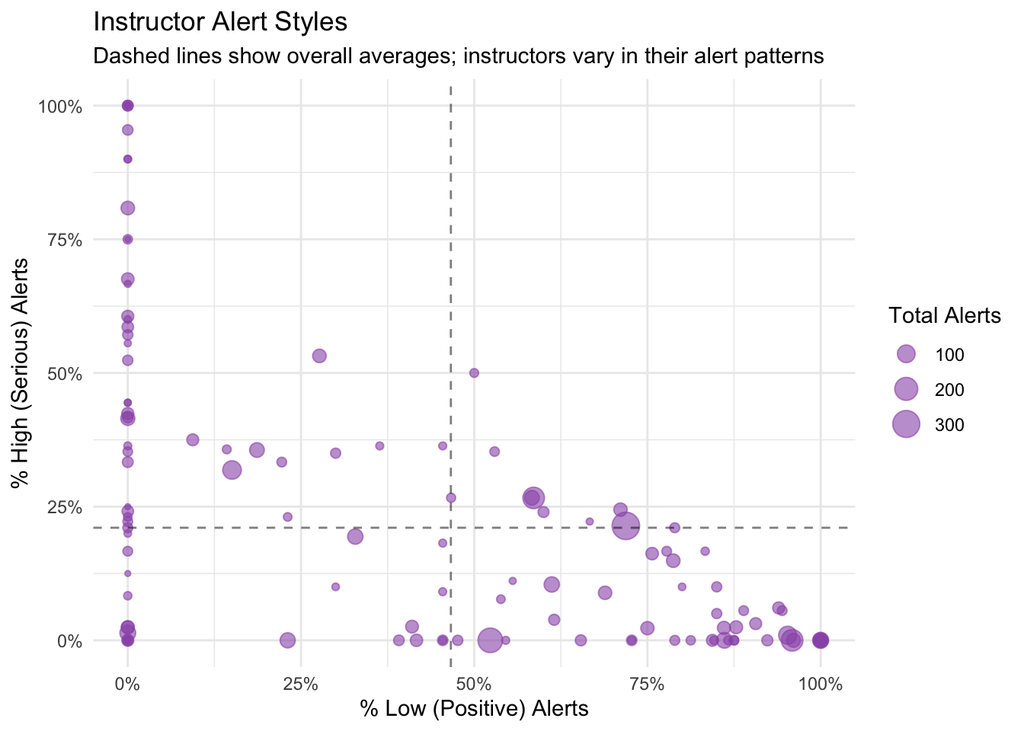

**Interpretation:** Instructors in the upper-left quadrant issue mostly warning alerts (few positive, many serious). Those in the lower-right issue mostly positive alerts. This reflects both course difficulty and individual instructor approaches to the alert system.

### Specific Courses with High Alert Volume

Courses with Most Alerts

| Course | Alerts | Students | % Low | % High | Fail Rate |
| --- | --- | --- | --- | --- | --- |
| CHEM 231 - Organic Chemistry I | 482 | 431 | 67% | 24% | 13% |
| BIOL 114 - Intro to Organisms & Pops Biol | 237 | 237 | 52% | 0% | 5% |
| HARP 170 - FRI Research Methods | 207 | 203 | 93% | 0% | 1% |
| PSYC 111 - General Psychology | 193 | 166 | 9% | 19% | 26% |
| WRIT 111 - Inquiry and Academic Writing | 93 | 76 | 56% | 25% | 25% |
| GEOG 151 - World Regional Geography | 92 | 92 | 99% | 0% | 2% |
| MATH 224 - Differential Calculus | 77 | 70 | 31% | 22% | 23% |
| BIOL 113 - Intro to Cell & Molecular Biol | 73 | 71 | 0% | 1% | 12% |
| PSYC 344 - Research Methods (LEC) | 65 | 48 | 6% | 68% | 42% |
| CHEM 105 - General Chemistry II | 63 | 63 | 65% | 10% | 11% |
| ANTH 167 - Introduction to Archaeology | 60 | 48 | 58% | 27% | 17% |
| CHEM 106 - General Chemistry Lab (LEC) | 59 | 40 | 19% | 36% | 22% |

## 3. Student Outcomes Analysis

### Overall Pass/Fail Rates

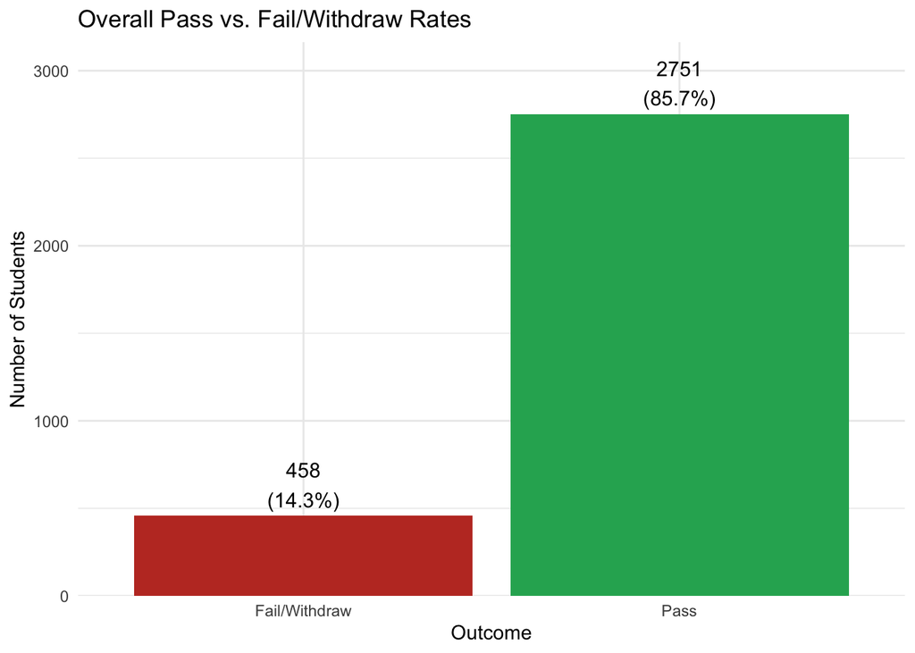

### Outcomes by Alert Level

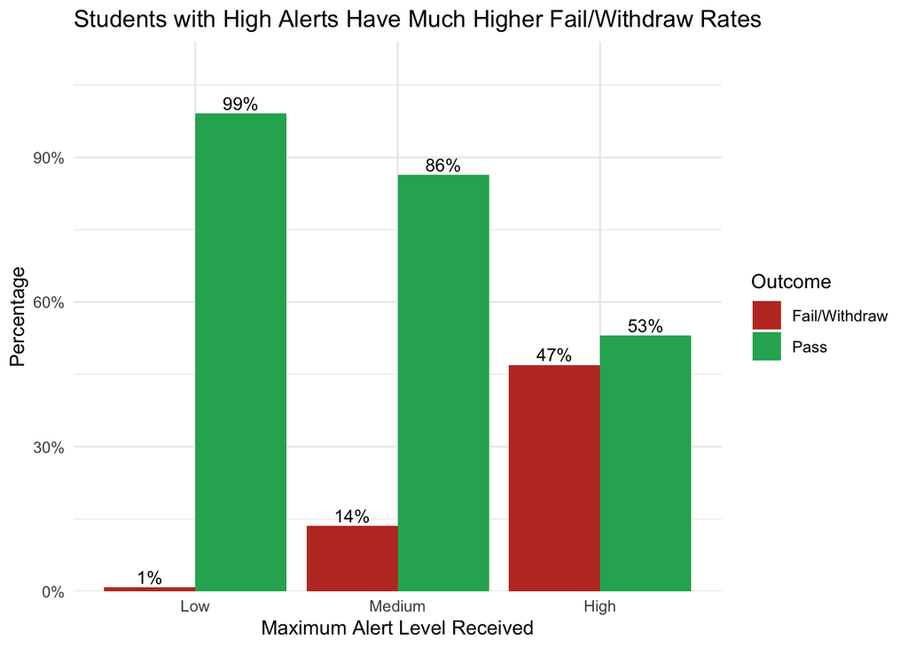

### Outcomes by Academic Standing

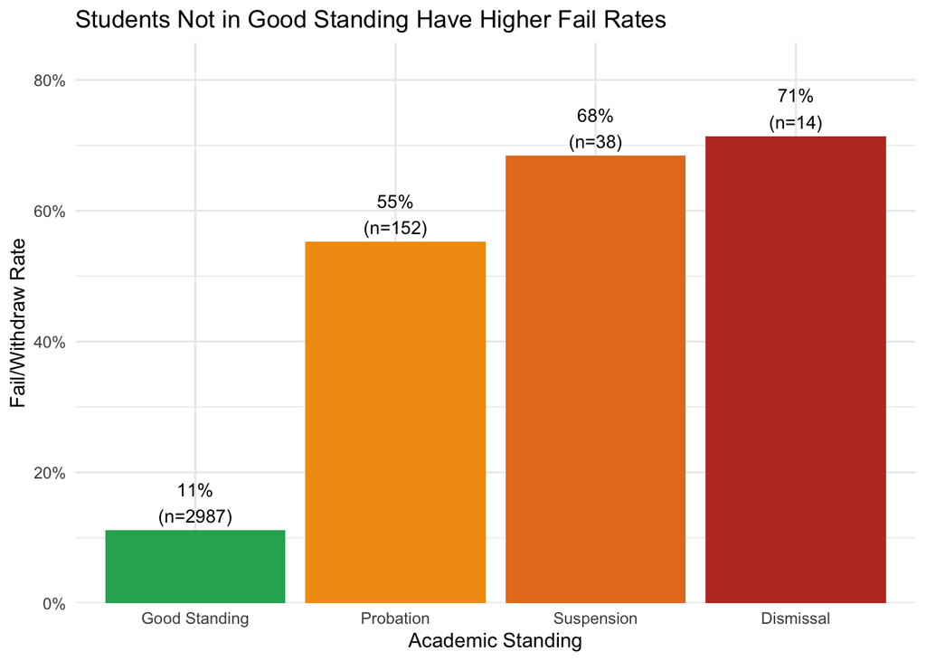

## 4. Special Populations: EOP, Athletes, and SSS Students

### Overview of Special Populations

Student Counts by Population

| Group | Count |
| --- | --- |
| Total Students | 3250 |
| EOP Students | 10 |
| Athletes | 65 |
| SSS Students | 206 |

### Alert Levels by Population

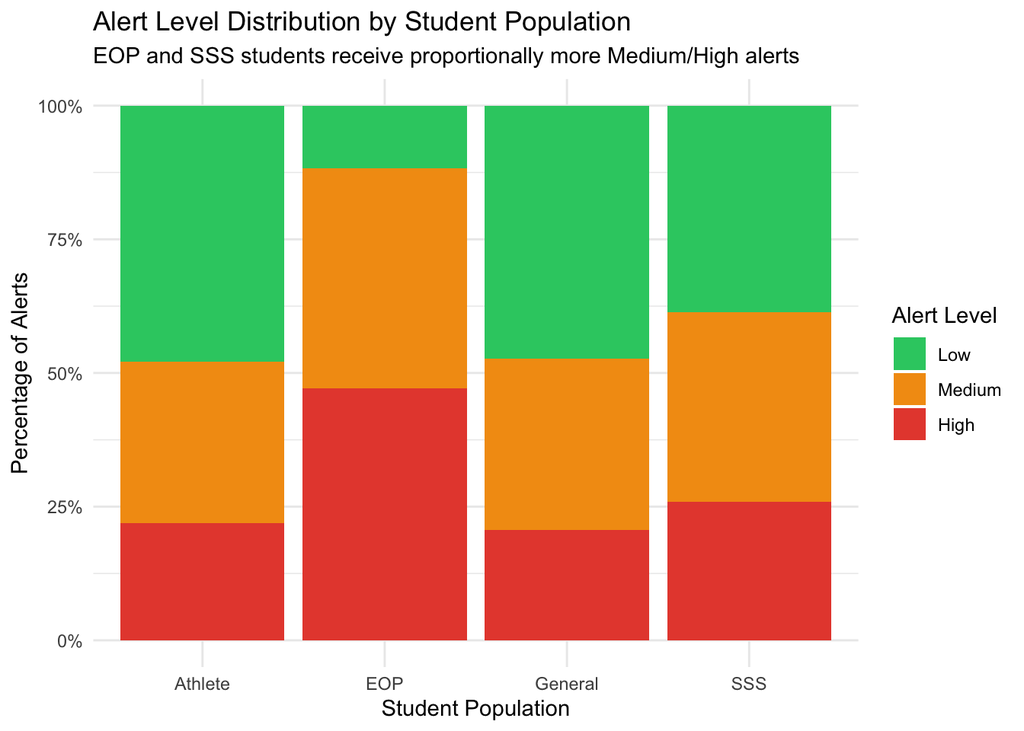

Alert Distribution by Population (count and percentage)

| Population | Low | Medium | High |
| --- | --- | --- | --- |
| Athlete | 35 (48%) | 22 (30%) | 16 (22%) |
| EOP | 2 (12%) | 7 (41%) | 8 (47%) |
| General | 1987 (47%) | 1348 (32%) | 865 (21%) |
| SSS | 113 (39%) | 104 (35%) | 76 (26%) |

### Outcomes by Population

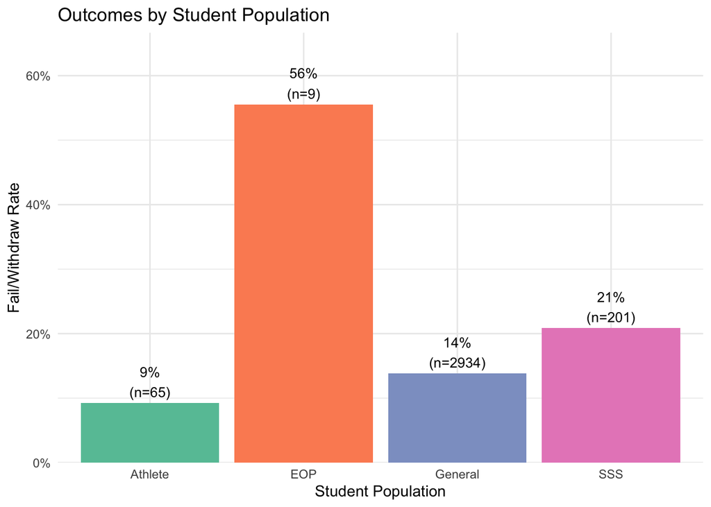

### Which Departments Are Special Populations Taking?

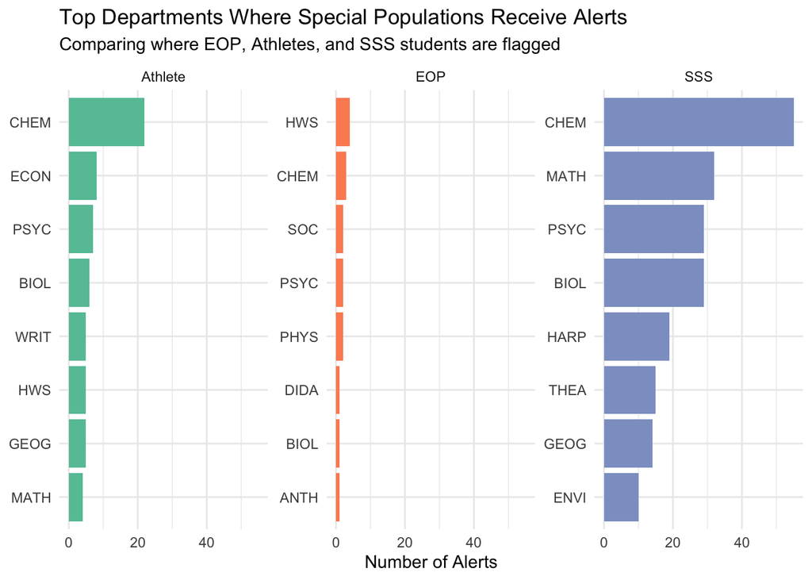

### GPA Comparison Across Populations

[figure not shown]

### Do Special Populations Differ After Accounting for GPA?

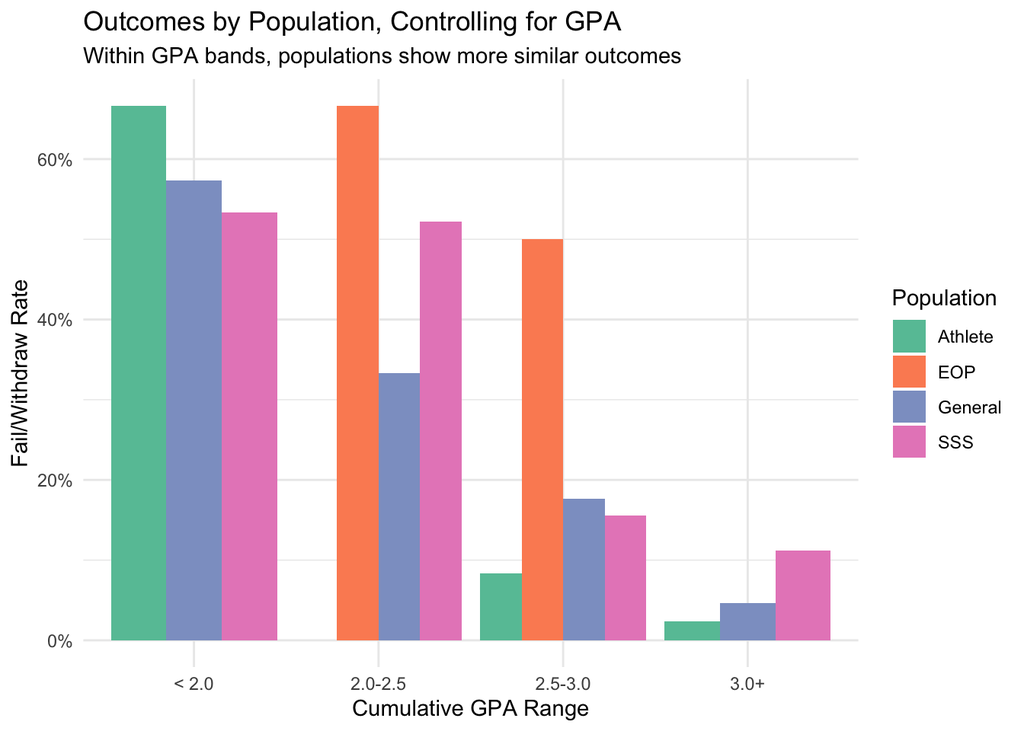

## 5. Predicting Outcomes: What Factors Matter Most?

We used a statistical model (logistic regression) to understand which factors best predict whether a student will fail or withdraw from a course. Rather than showing technical statistics, we present the results as **predicted probabilities** - the estimated chance of failing for different types of students.

### The Impact of GPA

[figure not shown]

### Comparing Risk Factors

To understand how different factors affect outcomes, we compare predicted fail probabilities for hypothetical students. We start with a **typical student** (2.5 GPA, Good Standing, received a Medium alert) and then change one factor at a time to see how much it matters.

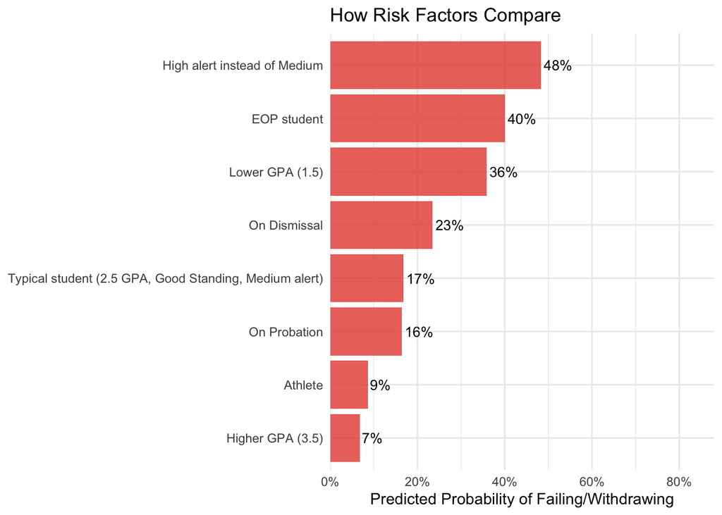

### Practical Probability Table

Predicted Fail/Withdraw Probability by GPA and Alert Level (Good Standing students)

| GPA | Low | Medium | High |
| --- | --- | --- | --- |
| 1.5 | 6% | 36% | 72% |
| 2.0 | 4% | 25% | 61% |
| 2.5 | 2% | 17% | 48% |
| 3.0 | 1% | 11% | 36% |
| 3.5 | 1% | 7% | 25% |

**How to read this table:** A student with a 2.5 GPA who received a High alert has approximately the probability shown in the table of failing or withdrawing from that course. Students with higher GPAs and lower alert levels have much better odds.

## 6. Using Low Alert Students as a Pseudo-Control Group

### The Idea

Students receiving **Low alerts** (compliments like “Keep up the good work!”) weren’t flagged for problems - instructors simply noticed them doing well. These students might approximate what happens “naturally” without warning or intervention. If we assume this, we can:

1. Build a model of the GPA → outcome relationship using **only** Low alert students
2. Apply that model to Medium/High alert students to predict their “expected” outcomes
3. Compare actual outcomes to expected outcomes

If actual outcomes are **better than expected**, it might suggest alerts + intervention helped. If actual outcomes are **worse than expected**, either intervention didn’t help or these students have unmeasured risk factors.

### Profiling Low Alert Students

First, let’s see who the Low alert students are:

Comparing Low Alert Students to Medium/High Alert Students

| Characteristic | Low Alert Students | Medium/High Alert Students |
| --- | --- | --- |
| N | 1589 | 1620 |
| Mean Cumulative GPA | 3.6 | 2.72 |
| Median Cumulative GPA | 3.69 | 2.83 |
| % Good Standing | 100% | 88% |
| % EOP | 0% | 0% |
| % Athlete | 2% | 2% |
| % SSS | 5% | 7% |
| Pass Rate | 99% | 73% |

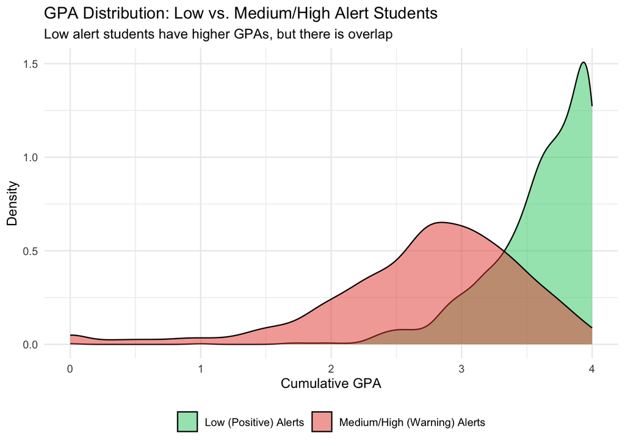

### Building the Baseline Model

We fit a model using **only Low alert students** to estimate the “natural” relationship between student characteristics and outcomes - what happens when students are doing fine and just happen to get noticed positively.

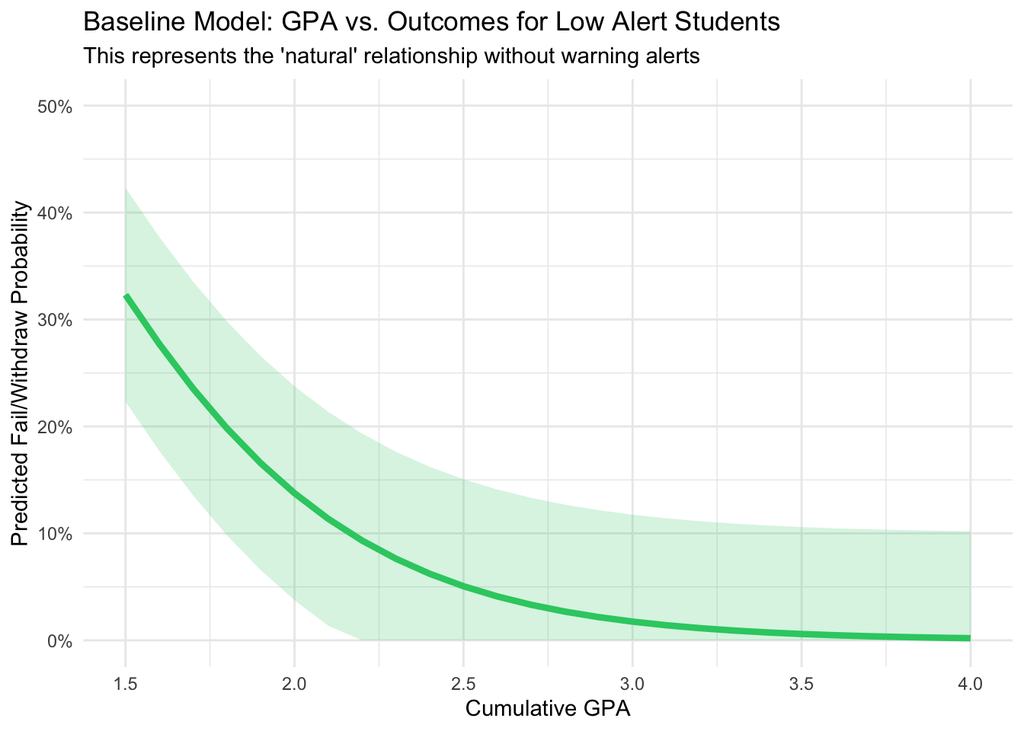

### Applying the Baseline to Medium/High Alert Students

Now we apply the baseline model to students who received Medium or High alerts. This gives us their **expected** fail rate based on what we’d predict for Low alert students with similar characteristics.

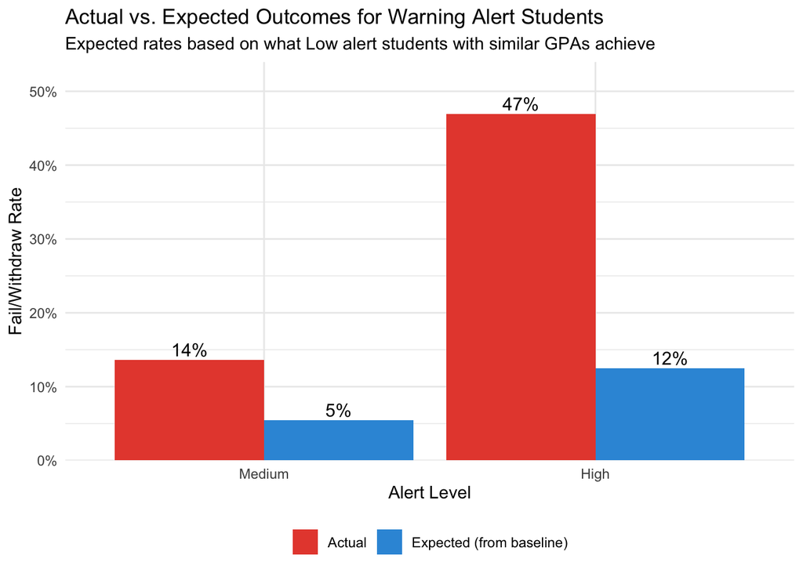

Actual vs. Expected Fail Rates for Medium/High Alert Students

| Alert Level | N | Actual Fail Rate | Expected Fail Rate | Difference |
| --- | --- | --- | --- | --- |
| Medium | 949 | 13.6% | 5.5% | +8.1% |
| High | 671 | 46.9% | 12.5% | +34.5% |

### Breaking Down by GPA

To see if the pattern holds across different GPA ranges:

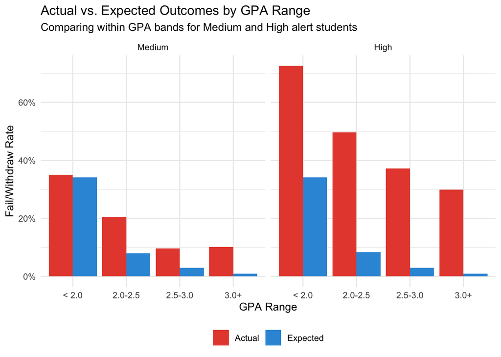

### Individual-Level Analysis

How many students did better or worse than expected?

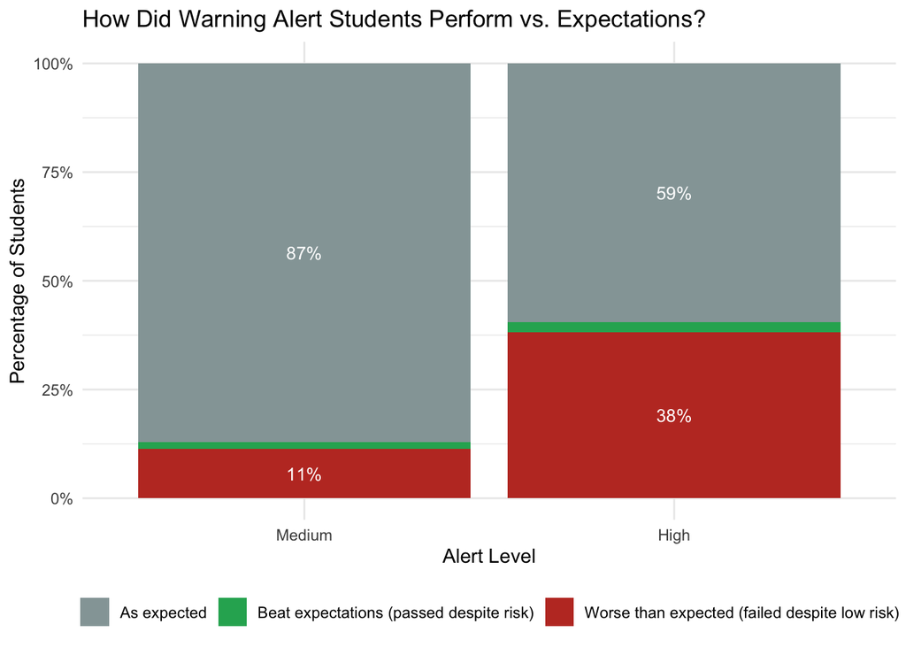

### Statistical Test

Is the difference between actual and expected statistically significant?

Statistical Comparison: Actual vs. Expected Fail Rates

| Alert Level | N | Actual Fail Rate | Expected Fail Rate | Difference | p-value |
| --- | --- | --- | --- | --- | --- |
| Medium | 949 | 13.6% | 5.5% | +8.1% | < 0.001 |
| High | 671 | 46.9% | 12.5% | +34.5% | < 0.001 |

### Interpretation

**What the analysis shows:**

- **Medium alert students** have an actual fail rate that is higher than expected by 8.1% percentage points
- **High alert students** have an actual fail rate that is higher than expected by 34.5% percentage points

**How to interpret this:**

If actual fail rates are **higher than expected**, this suggests that:

1. Medium/High alert students have unmeasured risk factors (motivation, personal issues, course difficulty) beyond what GPA and academic standing capture, OR
2. The alerts/interventions weren’t sufficient to close the gap, OR
3. Both factors are at play

If actual fail rates were **lower than expected**, it would suggest interventions might be helping students perform better than their characteristics would predict.

### Important Caveats

This analysis relies on several assumptions that may not fully hold:

1. **Low alert students as “typical”**: Students who received positive alerts may be *slightly better* than average - instructors noticed something positive about them. This would bias our “expected” rates downward, making the gap appear larger than it truly is.
2. **Course differences**: Low alert students might be in different (perhaps easier) courses than students receiving warning alerts for the same GPA. We’re comparing across different contexts.
3. **The compliment effect**: Receiving positive feedback might itself improve outcomes for Low alert students, meaning they’re not a pure “no intervention” group.
4. **Timing**: We don’t know when alerts were issued relative to when students’ outcomes were determined. Early alerts allow more time for intervention.
5. **Selection into alerts**: Instructors who submit alerts may teach differently, or have different student populations, than those who don’t.

**Bottom line**: This analysis provides suggestive evidence about the gap between actual and expected outcomes, but cannot definitively prove whether alerts and interventions are effective. The true counterfactual - what would have happened to these students without alerts - remains unknown.

## 7. Summary

Key Summary Statistics

[output not shown]